# Plate reader growth curves of GAT201 mutants in RPMI and CO2-independent media

Liz Hughes & Edward Wallace

23/05/2023

# Summary

Plate reader growth curves of WT KN99-alpha and gat201∆ deletion mutant Madhani in RPMI and CO2 independent media.

- 5 Bioreps, 3 Techreps each.
- Grow 5ml culture from colony (1 colony = 1 Biorep) in YPD, 30C, 180 rpm ON.
- Seed at OD 600nm = 0.2 , 200 ul per well.
- Run for 3 days (400 cycles).

# Set up data frame of nice strain names, colours, styles.

```r
strain_df <- tibble( Strain      = c("KN99",   "GAT201"),
                     Strain_nice = c("GAT201", "gat201∆m"),
                     colour      = c("grey20", "darkred"))
```

# RPMI media analysis

## Read in raw data

```r
raw_od <-
  here::here("data", "20221216_PR27_RPMIvCO2Indep.xlsx") %>%
  read_platereader_xlsx(start_row = 52)
```

## Read in the Plate map data from csv file RPMI

Also combine with nice strain names for display.

```r
platemap <-
  here::here("data", "20221216_PR27_RPMIvCO2Indep_Setup.csv") %>%
  read_platemap_csv(strain_df = strain_df)

head(platemap, n=10)
```

```
## # A tibble: 10 × 7
##    Well  Strain Biorep Techrep Media Strain_nice colour
##    <chr> <chr>   <dbl>   <dbl> <chr> <chr>       <chr>
##  1 A1    <NA>       NA      NA R     <NA>        <NA>
##  2 A2    <NA>       NA      NA R     <NA>        <NA>
##  3 A3    <NA>       NA      NA R     <NA>        <NA>
##  4 A4    <NA>       NA      NA R     <NA>        <NA>
##  5 A5    <NA>       NA      NA R     <NA>        <NA>
##  6 A6    <NA>       NA      NA R     <NA>        <NA>
##  7 A7    <NA>       NA      NA CO2   <NA>        <NA>
##  8 A8    <NA>       NA      NA CO2   <NA>        <NA>
##  9 A9    <NA>       NA      NA CO2   <NA>        <NA>
## 10 A10   <NA>       NA      NA CO2   <NA>        <NA>
```

## Reshape data and combine with the plate map, pairing them by Well

And split into RPMI and CO2indep

```r
annotated_od <-
  reshape_annotate_raw_od(raw_od = raw_od, platemap = platemap)

annotated_od_RPMI <- annotated_od %>%
  dplyr::filter(Media == "R")

annotated_od_CO2i <- annotated_od %>%
  dplyr::filter(Media == "CO2")
```

## Plot blank ODs

To find how stable the ODs of the blank wells are.

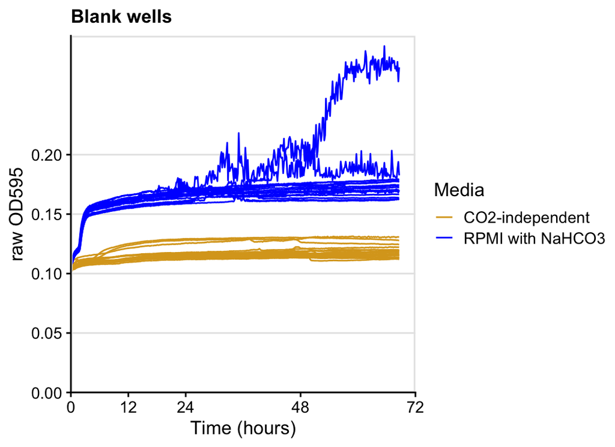

```r
ggplot(data=filter(annotated_od, is.na(Strain)),
       aes(x=Time, y=OD595,  group = Well, colour = Media)) +
  geom_line() +
  scale_time_hrs() +
  scale_y_continuous(limits = c(0, 0.3),
                     expand = c(0, 0),
                     breaks = c(0, 0.05, 0.1, 0.15, 0.2)) +
  labs(title = "Blank wells", x="Time (hours)", y="raw OD595") +
  scale_colour_manual(values = c("R" = "blue", "CO2" = "goldenrod"),
                      labels = c("R" = "RPMI with NaHCO3", "CO2" = "CO2-independent"))
```

This shows that the OD increases over time, presumably pH change of the phenol red indicator. And it is very different in the two media.

## Calculate median OD for blank wells

```r
# filter out columns 1 and 12 as well?
blank_od_summary <-
  annotated_od %>%
  dplyr::group_by(Media) %>%
  summarise_od_fixed(od.name = "OD595",
                     is.na(Strain))

print(blank_od_summary)
```

```
## # A tibble: 2 × 5
## # Groups:   Media [2]
##   Media OD_median OD_mean OD_max OD_min
##   <chr>     <dbl>   <dbl>  <dbl>  <dbl>
## 1 CO2       0.115   0.116  0.131  0.101
## 2 R         0.167   0.167  0.291  0.101
```

```r
blank_od_time <-
  annotated_od %>%
  dplyr::group_by(Media) %>%
  summarise_od_bytime(od.name = "OD595",
                     is.na(Strain),
                     Well != "H2")

print(blank_od_time)
```

```
## # A tibble: 400 × 5
## # Groups:   Time [400]
##     Time OD_median_time OD_mean_time OD_max_time OD_min_time
##    <dbl>          <dbl>        <dbl>       <dbl>       <dbl>
##  1 0              0.126        0.119       0.169       0.101
##  2 0.172          0.127        0.123       0.172       0.102
##  3 0.344          0.130        0.125       0.177       0.103
##  4 0.516          0.132        0.128       0.181       0.104
##  5 0.688          0.134        0.130       0.185       0.104
##  6 0.860          0.137        0.132       0.187       0.104
##  7 1.03           0.139        0.134       0.188       0.104
##  8 1.20           0.142        0.135       0.190       0.105
##  9 1.38           0.144        0.137       0.190       0.105
## 10 1.55           0.145        0.138       0.192       0.105
## # … with 390 more rows
```

## Subtract blank OD to make corrected OD RPMI

First check and filter out wells with weird traces, from the blank OD plot above we want to remove wells that go over OD = 0.18

```r
bad_blank_wells <- annotated_od_RPMI %>%
  dplyr::filter(OD595 > 0.18, is.na(Strain)) %>%
  dplyr::pull(Well) %>%
  unique()

bad_blank_wells
```

```
## [1] "A1" "A2"
```

```r
normalised_od_RPMI <-
  annotated_od_RPMI %>%
  dplyr::filter(!(Well %in% bad_blank_wells)) %>%
  normalise_od_2ways(is.na(Strain))
```

## Plot OD corrected by time-based median summary RPMI

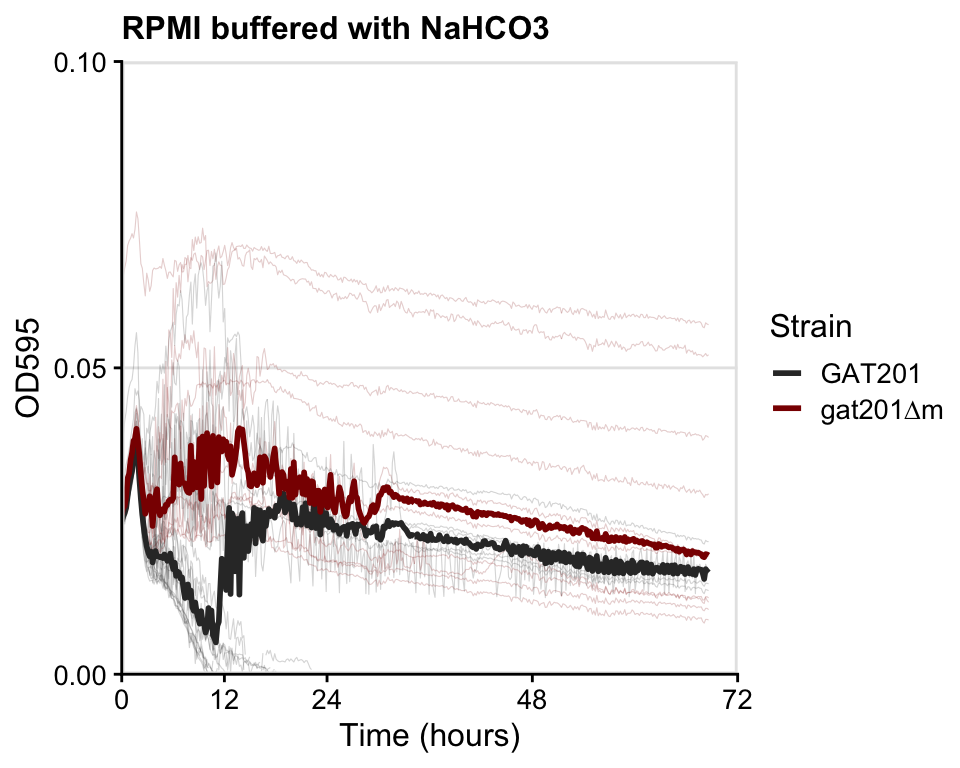

```r
RPMI_plot <-
  ggplot_growthcurve_summary(data_od = normalised_od_RPMI %>%
                               filter(!is.na(Strain)),
                             value_od = "OD_corrected_time",
                             limits_time = c(0,72),
                             limits_od = c(0, 0.1),
                             breaks_od = c(0, 0.05, 0.1)) +
  scale_color_strain(strain_df)  +
  labs(title = "RPMI buffered with NaHCO3")

RPMI_plot
```

## Plot OD corrected by time-based median summary RPMI

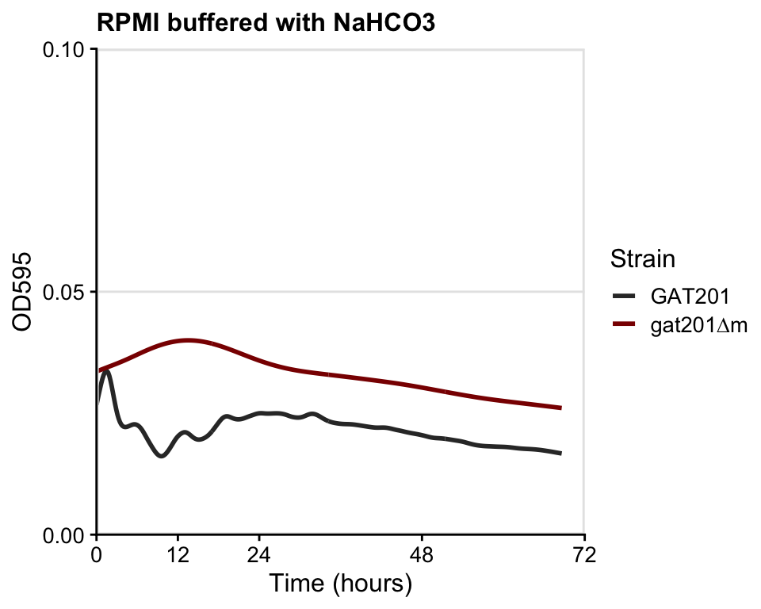

```r
RPMI_spline_plot <-
  ggplot_growthcurve_spline(data_od = normalised_od_RPMI %>%
                              filter(!is.na(Strain)),
                            value_od = "OD_corrected_time",
                            limits_time = c(0,72),
                            limits_od = c(0, 0.1),
                            breaks_od = c(0, 0.05, 0.1)) +
  scale_color_strain(strain_df)  +
  labs(title = "RPMI buffered with NaHCO3")

RPMI_spline_plot
```

## Subtract blank OD to make corrected OD CO2i

```r
normalised_od_CO2i <-
  normalise_od_2ways(annotated_od_CO2i, is.na(Strain))
```

## Plot OD corrected by time-based median summary CO2i

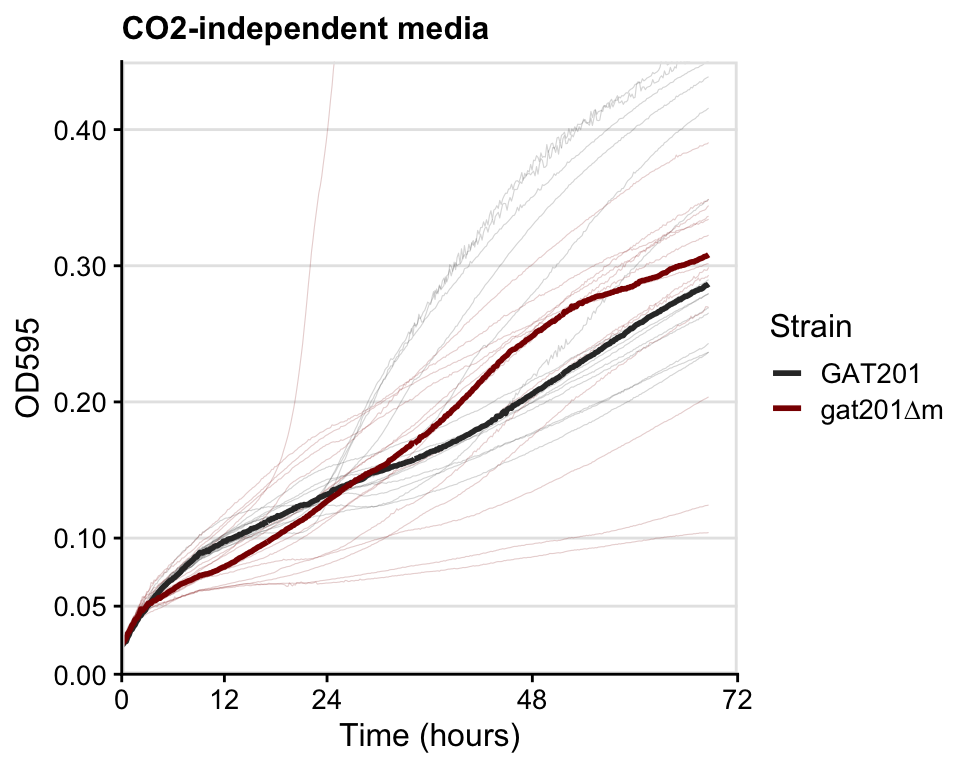

```r
CO2i_plot <-
  ggplot_growthcurve_summary(data_od = normalised_od_CO2i %>%
                               filter(!is.na(Strain)),
                             value_od = "OD_corrected_time",
                             limits_time = c(0,72),
                             limits_od = c(0, 2),
                             breaks_od = c(0, 0.05, 0.1, 0.2, 0.3, 0.4)) +
  scale_color_strain(strain_df)  +
  coord_cartesian(ylim = c(0,0.45)) +
  labs(title = "CO2-independent media")

CO2i_plot
```

## Plot OD corrected by time-based median summary CO2i

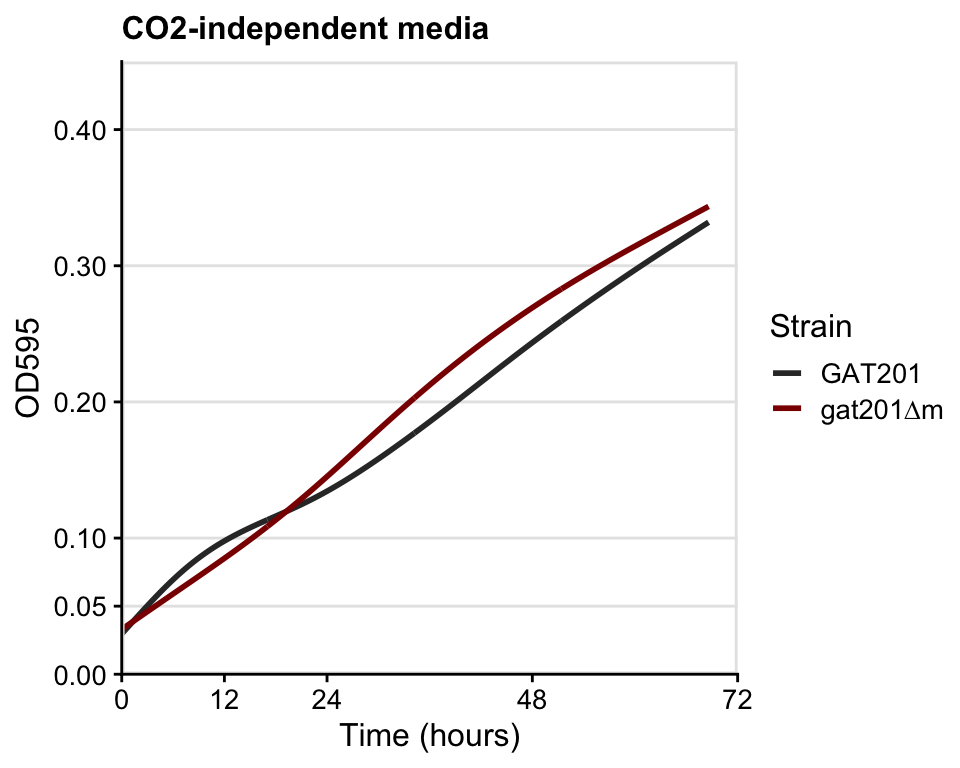

```r
CO2i_spline_plot <-
  ggplot_growthcurve_spline(data_od = normalised_od_CO2i %>%
                              filter(!is.na(Strain)),
                            value_od = "OD_corrected_time",
                            limits_time = c(0,72),
                            limits_od = c(0, 2),
                            breaks_od = c(0, 0.05, 0.1, 0.2, 0.3, 0.4)) +
  scale_color_strain(strain_df)  +
  coord_cartesian(ylim = c(0,0.45)) +
  labs(title = "CO2-independent media")

CO2i_spline_plot
```

# Multipanel Figure combining RPMI and CO2i results

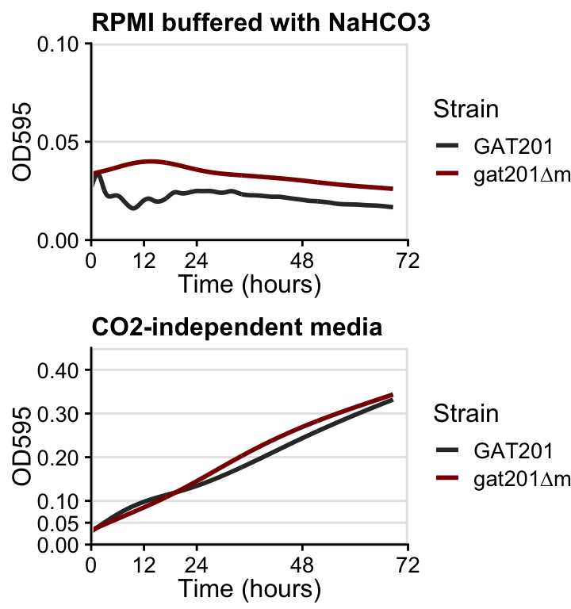

```r
multi_plot <-
  plot_grid(
    RPMI_spline_plot,
    CO2i_spline_plot,
    ncol = 1)

multi_plot
```

```r
here::here("results",
           "fig_growthcurves_RPMI_CO2independent.png") %>%
  ggsave(plot = CO2i_spline_plot,
         width = 3.75, height = 3)
```